# Introduction to Network Analysis

The aim of these 2 classes is to present some notions and concepts of complex network theory that could be used during the course of the master and even after. During the lectures we alternate between theroetical definitions of several measures and how to practically estimate them using python function. To this end, before starting, some Python packages need to be installed:

```
1. networkx: this package contains the functions to handle network objects and estimate network measures
2. matplotlib: this package contains function for plotting results
3. scipy and numpy: that contains  mathematical functions
4. pandas: to use and transform dataset
```

The command to import the packages are shown below

```python
import networkx as nx
import matplotlib.pyplot as pl
import numpy as np
import scipy as sp
import pandas as pd
import seaborn as sns
```

```
First Day - Notations and definition

- Example of real life complex network and definition
- Centrality measures
- Global measures

Second Day -Complex network's properties

- Feedback on assignments
- The importance of degree distribution
- Modeling networks and the small world effect
- Cohesiveness and resilience of a network
- Community detection
```

We use a couple of toy networks (files toy_network_1.csv and toy_network_2.csv).

They are small compared to real world ones but they provide a way to introduce concepts.

This course is a very short introduction to complex network theory -> not exhaustive.

If you are interested in the topic and would like to go more in detail in some points you could read the book by (Menczer et al.) [https://www.cambridge.org/fr/academic/subjects/physics/statistical-physics/first-course-network-science] and by (Barabasi)[http://networksciencebook.com/] available online

Most of the images shown in this course, the nicest ones , are taken from these books.

# First Day

## Example of real life complex network and some definitions

[figure not shown]

```
- Facebook individuals are connected by a link of mutual friendship. Through this link  information can be exchanged and new acquaintances can be introduced
- Instagram/Twitter's users interact through following other users or retweeting their messages
- Internet is a network of computers and servers connected among them. Through their connections information can be exchanged
- World Wide Web is a set of webpages with (hyper)links pointing among them. From one page you can jump to another one


 - Transportation network: Cities are connected through the flights connecting airports. The intensity of movements to and from airports helps identifiyng those who are important. Think about the difference between Paris Charles de Gaulle , New York JFK and Montpellier
 - Sexual relation  network: often built  using snowball sampling, starting from one patient identify people with whom he/she has sexual intercourses , and then questioning them. This type of network is important to study the diffusion of sexually transmitted diseases like chlamydia, HIV and Hepatitis
```

### Biological networks include:

```
- Gene regulatory network: in this case  genes , input and output are in relation among them due to the action that one element applies to the other ( blocking, catalysing etc...) that could result to the activation of specific gene
-Protein network : similarly  describe the interaction among proteins in regulating the activities of enzymes
-Neuron networks: synapses are connected among them and thorugh them electrical signals are transmitted
-Ecological network: identifying the relation among predators and preys in a specific ecosystem
```

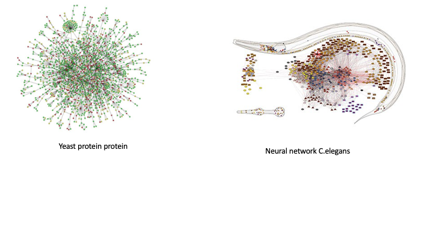

### Some Definitions:

Network: **Representation of an interacting system in terms of nodes (interacting entities) and links connecing 2 nodes (indicating if a relation exists between 2 entities)**

- **Node**: point in a network at which lines intersect . To each link is associated an identifiant (a letter , a number) to identify in the network. It corresponds to the interacting units. Besides structural properties nodes can have other characteristics (i.e. city name, population , age, sex, gene type)
- **Link**: rod connecting 2 nodes. It indicates the presence of an interaction between 2 nodes. Its identifiant is given by hte identifiant of its ends'nodes (i,j). As in the case of nodes, other characteristics of the link can be considered (weight, type of interaction, period etc..)
- **Neighbor**: 2 nodes at the ends of the same link (directly connected).
- **Loop**: link whose ends coincide

Through the network several phenomena can take place and properties/information/pathogens can flow.

Simplification of the complex system the interest is put on the structure of the network and how this can influence or can be influenced by the dynamic over it.

The science that has as object of study the analysis of network is *Complex Network theory* whose tools have been mutuated from differnt research fields. Although the concept of network was initially developed in the context of sociology, the field of research involved different type of networks defined by the type of interaction

| Type | Example | Objective | Node | Link |
| --- | --- | --- | --- | --- |
| Social | Facebook, Family | Friendship, family | Individuals | Friendship, Family relation. Links are reciprocal |
| Communication | Instgram, Twitter | Spread information at large scale | User | Retweet. Links can be undirected |
| Transportation | Airports,urban map | Flows of individuals, goods | Cities,countries | Flows due to flights Links are characterized by the volume of animals |
| Biological | Genetic Regulatory network | How cells/genes interact | Genes, proteins | Interaction spiking. Boolean: the activation depends on state of other components |

### Type of networks

Links,can be directed/oriented or undirected, weighted or unweighted -> network.

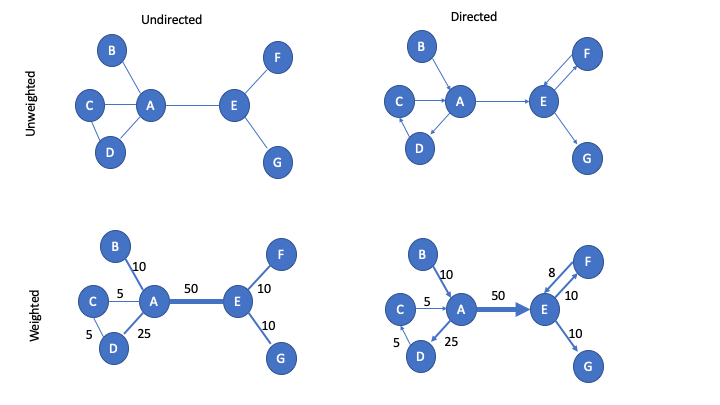

In an undirected network, the presence of a link between two nodes means that they are connected in both directions, whereas the presence of a link in a directed network does not necessarily imply the presence of a link in the opposite direction . Epidemiology: A disease that in an undirected network might spread to all nodes, in the same directed network might stop before reaching all of them because there are no connections in the "right direction".

Furthermore, some types of networks can be characterised by weights associated with their own links and are referred as weighted networks. In livestock mobility networks, for example, the volume of animals moved can be seen as the weight associated with the trade link between origin and destination.

This too can influence the spread of diseases because the greater the weight, and hence the volume of the herd, the greater the risk of presence of sick animals.

Sometimes the nodes of the same networks can interact in different ways (p.e. cities can be connected by different airlines) in this case we talk about *multiplex*

### Network's representation

Network data are usually collected through the use of surveys and could include hundreds if not thousands of nodes and even more links. Because of this the graphical represntation sometimes is not very informative. Depending on the context network can be represented in different forms:

```
- Matrix form: a square matrix (N X N) whose size corresponds to the number of nodes, with 1 if there is a link between two  nodes, 0 otherwise. In case of weighted network the entries ae number whose values correspond to the weight of the link. From a theoretical point of view is the most effective way of representing , but not in terms of storage (a lot of 0)
- Nodelist: for each node a list of all the neighbors
- Edgelist: a table  where each line correspond to a link
```

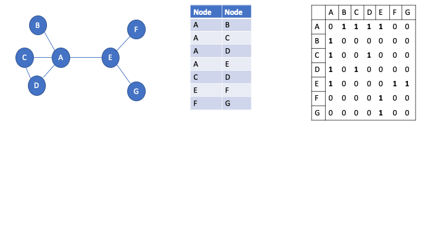

In our case the network data are in the form of an edgelist. In the following we show how data can be imported using networkx

### Importing network data in python

-) Importing as a undirected network. We create an object Graph, through the function **nx.Graph**.

```python
df = pd.read_csv("toy_network_1.csv",sep=";")
Graphtype = nx.Graph()
Gund = nx.from_pandas_edgelist(df,source="Origin",target="Destination",edge_attr=None,  create_using=Graphtype)
```

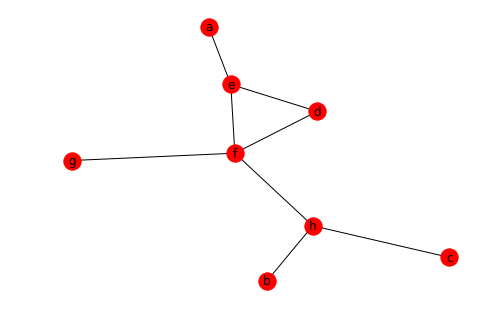

```python
nx.draw(Gund,with_labels=True)
```

-) as a direct graph. We create a direct graph using the function **nx.Digraph**. Source and target identify the columns to consider as tail and the head of the arrows

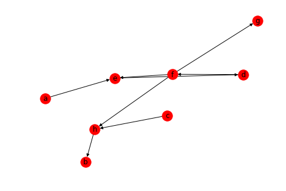

```python
Graphtypedir = nx.DiGraph()
Gdir = nx.from_pandas_edgelist(df,source="Origin",target="Destination",edge_attr=None,  create_using=Graphtypedir)
nx.draw(Gdir,with_labels=True)
```

-) And as a direct weighted network. In this case we need to indicate the weights column

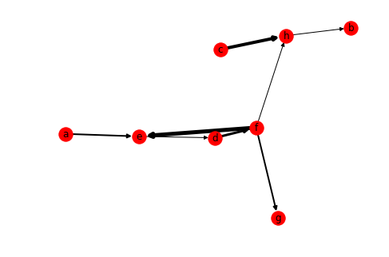

```python
Gdirw = nx.from_pandas_edgelist(df,source="Origin",target="Destination",edge_attr="Weight",  create_using=Graphtypedir)
weights = nx.get_edge_attributes(Gdirw,'Weight').values()
nx.draw(Gdirw,with_labels=True,width=weights)
```

In the case of small networks, few nodes and links, the representation fo a network is quite easy. Complexity of representation quickly increases with the number of nodes **and, most importantly, links**.

Ad-hoc software have been developed to display network. We reccommend to have a look at the [Gephi software](https://gephi.org/).

# Network measures

Network measures are used to define structural properties , classify nodes in the network, but also to compare different networks. We can classify the measures in 2 broad categories:

```
- Centrality measures: defined for each node
- Global measures:  global structural property of the network in its completeness
```

In the following we consider an undirected , unweighted network although the definition for the centrality measures can be easily extended to oriented and weighted network. When needed we'll discuss the correspective wieghted and oriented counterparts.

In the following we indicate with :

- **Size** (N) of a network , the number of nodes in a network
- **Number of links** (L) of a network, the total number of links present in a network. The function for estimating **L** is number_of_edges()

```python
Gund.number_of_edges()
```

```
8
```

## Centrality Measures

Centrality measures are used to quantify the importance of nodes and/or links in a network with respect a specific characteristic.

Among them, the most common are the degree,the clustering coefficient, the betweenness, the closeness and eigenvalue centrality.

A modification of the definition of eigenvalue centrality , it has actually used to develop the PageRank algorithm and used in the Google search engine.

### Degree

**Degree**: the degree $k_i$ of a node $i$ is defined as the number of links connecting it to other nodes or , alternatively , the number of neighbors a node has. When a network is directed, we call in-degree $k_i^{in}$ the links pointing at $i$ and out-degree $k_i^{out}$ the links originating from i.

A node with degree null is called a *singleton*.

High-degree nodes are called *hubs* -> role is of utterly importance depending on the structure of the network.

Networkx allows to estimate the degree (in and out) for a specific node or for all nodes through the function degree whose syntax is shown below

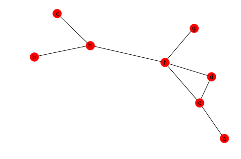

```python
nx.draw(Gund,with_labels=True)
```

For a node "f" in a undirected network

```python
Gund.degree("f")
```

```
4
```

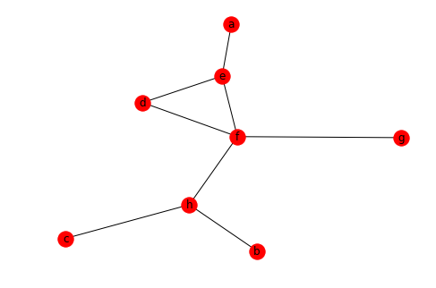

```python
nx.draw(Gund,with_labels=True)
```

For all nodes in an undirect network

```python
Gund.degree()
```

```
DegreeView({'a': 1, 'c': 1, 'b': 1, 'e': 3, 'd': 2, 'g': 1, 'f': 4, 'h': 3})
```

The average (in/out) degree of a node is estimated summing over all nodes' degree in the network and dividing by the size of the network

$<k>=\frac{\sum_i k_i}{N}$

We can immagine each node as a "star" with the number of arms equals to the degree (stubs). Thus a link is formed when 2 stubs join together. The total number of link $L$ is related to the the average degree by the relation

$L=\frac{\sum_i k_i}{2}=N\frac{<k>}{2}$

In the case of oriented network the above relation becomes:

This will become important when considering the connectivity properties of the network

### Strength

An extension of the degree definition in the case of a weighted network is the strenght. Indicating with $w_{ij}$ the weight of the link $(i,j)$ the strength of a node $i$ is obtained summing all the weights of the links $i$ is part of

$s_i=\sum_j w_{ij}$

where the sum is extended to all the $i$'s neighbors In networkx to estimate the strength for a specific node or all the network , and also for incoming and out going links, we use the function degree with the option weight

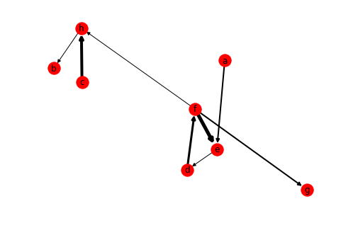

```python
nx.draw(Gdirw,with_labels=True,width=weights)
```

```python
Gdirw.degree(weight="Weight")
```

```
DiDegreeView({'a': 2, 'c': 4, 'b': 2, 'e': 8, 'd': 2, 'g': 3, 'f': 10, 'h': 7})
```

### Clustering coefficient

In real-world social network, it is common that 2 friends of a person are also friends

- **triads**, i.e; a set of 3 nodes connected by 2 links,
- **triangles**, a set of 3 nodes completely connected.

The clustering coefficient: is the fraction of pairs of node's neighbors , that are actually connected to each other.

Given a node $i$ of degree $k_i$ the coefficient can be estimated as the fraction of links present among the neighors (that complete the triangles $i$ is a vertex of, $\tau(i)$) over all possible connections among its $k_i$ neighbours $\frac{k_i(k_i-1)}{2}$ :

$C(i)=\frac{2\tau(i)}{k_i(k_i-1)}$

A high value of $C(i)$ indicates there are a lot of triangles in the netowrk , and nodes are clustered. This happens when individuals shared common elements (*homophily*). On the other hand , the fact of being surrounded by nodes with similar characteristics , could bring nodes to become more similar (*social influence*)

The networkx function to estimate the clustering coefficient is **nx.clustering**

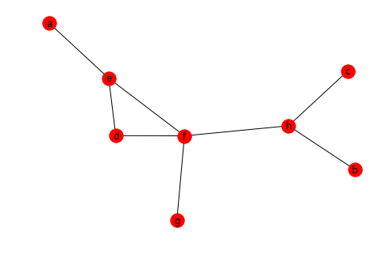

```python
nx.draw(Gund,with_labels=True)
```

```python
nx.clustering(Gund)
```

```
{'a': 0,
 'b': 0,
 'c': 0,
 'd': 1.0,
 'e': 0.3333333333333333,
 'f': 0.16666666666666666,
 'g': 0,
 'h': 0}
```

A network , for whom the clustering coeffecient of each node is identically 0 , is called a **tree**. In this case, if we cut one of the links the network remains automatically disconnected in 2 parts.

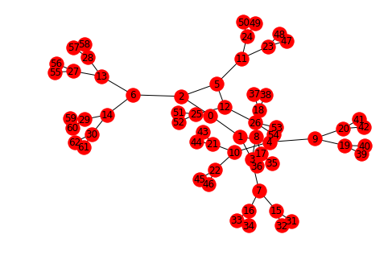

```python
tree=nx.generators.balanced_tree(2, 5)
nx.draw(tree,with_labels=True)
```

### Interlude: the definition of path and distance over network

The definition of degree, strength and clustering coefficient are definitions that are really local , that are focused only on the node and its neighbourhood. However, other measures have been developed to take account of the position of the node in the network , i.e. account of the centrality of the node. Before introducing these measures we need to define what is a path and the distance over a network. On a network there is not the same notion of a distance as in euclidean space: points that are geograhically closed are not supposed to be also "network -closed". Take the example of the airport network: to go from Montpellier to Rome , a traveler should go first to Paris and then fly to Rome , despite the fact that Rome is closer to Montpellier than Paris , there is no direct flight between the two locations.

- **Path** Within a network, the path connecting two nodes is defined as the sequence of links traversed to connect them, without crossing the same link twice (unique links). In the case of oriented network, the paths should consider also the orientation of the link.

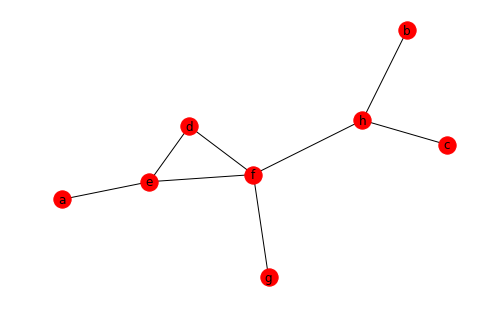

```python
nx.draw(Gund,with_labels=True)
```

In the figure above 2 possible paths connect the nodes $a,c$:

```
1. (a-e)(e-f)(f-h)(h-c)
2. (a-e)(e-d)(d-f)(f-h)(h-c)
```

The two paths are similar , however the second one has an extra link compared to the first one.

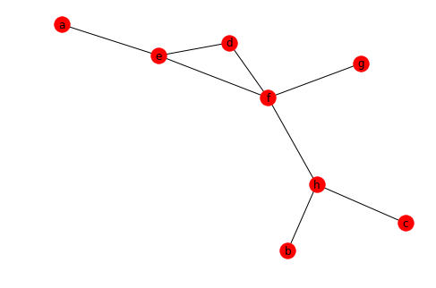

```python
nx.draw(Gund,with_labels=True)
```

#### Length of a path and distance

**Length** We indicate as length of the path the number of links crossed to connect 2 points.

**(geodesic) distance** between 2 nodes : the length of the shortest paths connecting the 2 points.

In case there isn't any path connecting 2 nodes the distance is assumed Infinite. This could happen in the case of directed network , when there is no path connecting the 2 following the direction of links

The networkx function for assessing the existence of path connecting nodes and the shortest distance are:

```python
nx.has_path(Gund,'a','c')
```

```
True
```

```python
nx.shortest_path(Gund,'a','c')
```

```
['a', 'e', 'f', 'h', 'c']
```

```python
nx.shortest_path_length(Gund,'a','c')
```

```
4
```

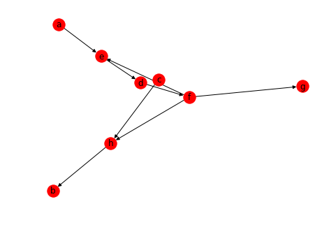

```python
nx.draw(Gdir,with_labels=True)
```

```python
nx.has_path(Gdir,'a','c')
```

```
False
```

#### Breadth-first Algorithm for finding shortest path

Finding the shortest path among nodes for large network is time consuming and algorithm should be put in place. The basic algorithm is *breadth first*. Starting from a source node $s$

```
- The neighbors are investigated and given distance 1 and put at layer 1. If 2 nodes are in layer1 they will not investigated again.
- The neighbors of nodes in the first layer that are not neighbors among them (i;e. does'nt not exist a link by 2 nodes in the same layer) are investigated and distance  2 is given to each node  and put in layer 2. If 2 nodes in layer2 are connected  they will not investigated again.
-The operation is repeated till all the nodes  are in  layers, or there are no more nodes to investigate.
```

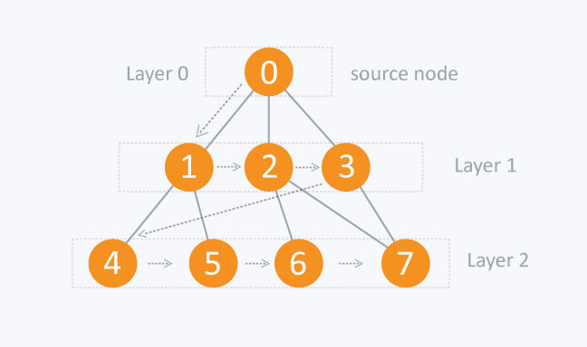

### Betweenness

**Betweenness**: the number of times a node acts as a waypoint along the shortest path between two other nodes;the betweenness (b) of $i$ is calculated as the fraction of paths that pass by $i$.

$\sigma_{hj}$ as the total number of shortest paths between nodes $h$ and $j$ $\sigma_{hj}(i)$ as the number of such paths passing through node $i$,

$$b_i=\sum_{h \neq i \neq j}\frac{\sigma_{hj}(i)}{\sigma_{hj}}$$

where the sum is done for each pair of distinct nodes $h$ and $j$, different from $i$ .

The higher the betweenness the higher is the involvement of the nodes in diffusion processes, the higher is the control on diffusion. In an epidemiology: most central nodes should be taken into consideration in surveillance systems, because of their higher risk of being infected by a disease and transmitting it .

Normalizationn :to the maximum number of paths that could pass through a node

$\frac{(N-2)(N-1)}{2}$

The function to estimate the betweenness is nx.betweenness_centrality

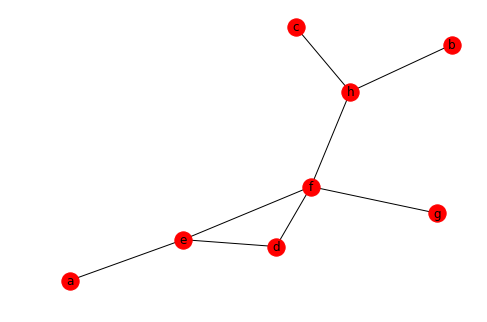

```python
nx.draw(Gund,with_labels=True)
```

```python
nx.betweenness_centrality(Gund)
```

```
{'a': 0.0,
 'b': 0.0,
 'c': 0.0,
 'd': 0.0,
 'e': 0.2857142857142857,
 'f': 0.7142857142857142,
 'g': 0.0,
 'h': 0.5238095238095237}
```

In general strong correlation between degree and betweennes

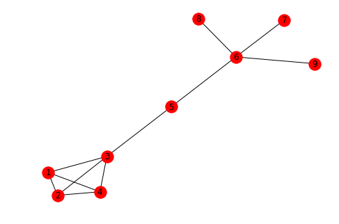

```python
Gbet=nx.Graph()
Gbet.add_edges_from([(1,2),(3,4),(1,3),(1,4),(2,4),(2,3),(3,5),(5,6),(6,7),(6,8),(6,9)])
nx.draw(Gbet,with_labels=True)
```

```python
nx.betweenness_centrality(Gbet)
```

```
{1: 0.0,
 2: 0.0,
 3: 0.5357142857142857,
 4: 0.0,
 5: 0.5714285714285714,
 6: 0.6428571428571428,
 7: 0.0,
 8: 0.0,
 9: 0.0}
```

#### Link's betweennes

The definition of betweenness can be extended to the links, considering the number of paths the link is part of. In this case the function is nx.edge_betweenness_centrality

```python
nx.edge_betweenness_centrality(Gbet)
```

```
{(1, 2): 0.027777777777777776,
 (1, 3): 0.16666666666666666,
 (1, 4): 0.027777777777777776,
 (2, 3): 0.16666666666666666,
 (2, 4): 0.027777777777777776,
 (3, 4): 0.16666666666666666,
 (3, 5): 0.5555555555555556,
 (5, 6): 0.5555555555555556,
 (6, 7): 0.2222222222222222,
 (6, 8): 0.2222222222222222,
 (6, 9): 0.2222222222222222}
```

### Closeness

where $l_{ij}$ is the shortest distance from $i$ to $j$ and the sum is done for all nodes in the network except $i$. The factor $N-1$, corresponding to the number of elements to be summed, has been introduce to make comparable between networks.

The shorter the path, the smaller the distance, the higher the proximity to a node.

Oriented network-> there are the in-closeness and the out-closeness.

Epidemiology: the in-closeness -> how quickly node will be infected; out-closeness tells us how quickly it will spreads the disease.

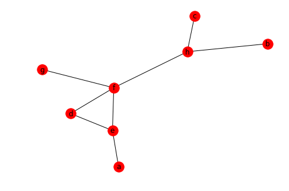

```python
nx.draw(Gund,with_labels=True)
```

```python
nx.closeness_centrality(Gund)
```

```
{'a': 0.3684210526315789,
 'b': 0.3888888888888889,
 'c': 0.3888888888888889,
 'd': 0.5,
 'e': 0.5384615384615384,
 'f': 0.7,
 'g': 0.4375,
 'h': 0.5833333333333334}
```

## Global Measures

The analysis of the network as a whole provides information on its overall structure. This is an important piece of information since it strongly influences the transmission and the propagation of diseases, or information among all the components.

Previous centrality measures can be averaged to provide mean values to compare 2 networks

To compare the "performances" of two networks global measures have been developed Two global measure have been already introduced:

- **Size** (N) of a network , the number of nodes in a network
- **Number of links** (L) of a network, the total number of links present in a network

Although these give some information about the "elements" present (nodes and links) other indicators needs to be used to study the characterize the structure of the network

### Density

The density $d$, defined as the ratio between the existing links $L$ and the maximum number of possible links that could exist in a network.

$$d=\frac{2*L}{N(N-1)}$$

A network with density equal 1 is said complete (all the nodes are connected among them). However when $d<<1$, a lot of links are missing and the network is said *sparse*. In general, we say that a network is sparse when $L\sim N$ , otherwise if $L \sim N^2$ the network is said dense.

The networkx function is nx.density

```python
nx.density(Gund)
```

```
0.2857142857142857
```

Using the relation between $L$, and average degree $<k>$ the above relation can be written as:

$$d=\frac{2*L}{N(N-1)}=\frac{2*<k>*N/2}{N(N-1)}=\frac{<k>}{(N-1)}$$

Density is the ratio between the average degree and the maximum possible one.

As we will se the density is an important indicator to estimate if a network is connected or not

### Diameter and average distance

The diameter $l_{max}$, defined as the maximum distance within the network, and the average path length $<l>$, defined as the average distance between each pair of nodes. The two measures are calculated as follows:

$l_{max}=max_{ij} l_{ij}$ i.e. maximum over all the possible shortest paths between any 2 nodes, and

$<l>=\frac{\sum_{ij}l_{ij}}{(N(N-1))}$, where i and j identify all pairs of nodes in the network .

The diameter and the average distance give an idea of the transmission speed within the network.

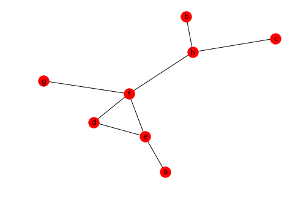

```python
nx.draw(Gund,with_labels=True)
```

```python
nx.diameter(Gund)
```

```
4
```

```python
nx.average_shortest_path_length(Gund)
```

```
2.142857142857143
```

### Connectivity of a network

A network is connected when there is at least one path, not necessarily direct, linking each node to all the others.

The largest connected component within a network is called **giant component** and when a network is connected, it corresponds to the entire network.

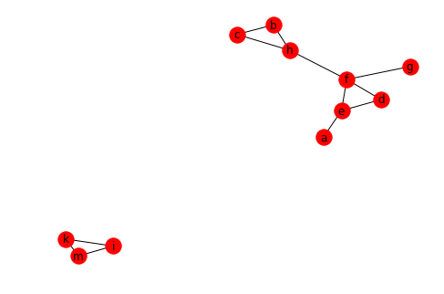

```python
df2 = pd.read_csv("toy_network_2.csv",sep=";")
Graphtype = nx.Graph()
Gund2 = nx.from_pandas_edgelist(df2,source="Origin",target="Destination",edge_attr=None,  create_using=Graphtype)
nx.draw(Gund2,with_labels=True)
```

```python
nx.is_connected(Gund2)
```

```
False
```

```python
comps=sorted(nx.connected_components(Gund2),key=len,reverse=True)
comps
```

```
[{'a', 'b', 'c', 'd', 'e', 'f', 'g', 'h'}, {'i', 'k', 'm'}]
```

### Connectivity in an oriented network

In the case of a directed network, the components are distinguished into weakly and strongly connected:

-**Weakly connected** :same connected components of the same undirected network,

-**Strongly connected** :subgroups of nodes in which there is at least one directed path linking each pair of nodes.

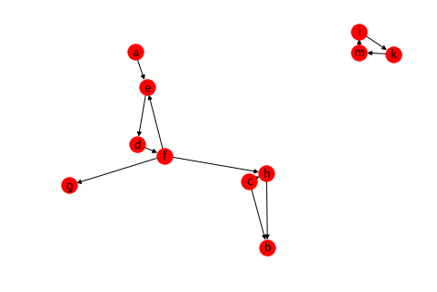

```python
Graphtype2 = nx.DiGraph()
Gdir2 = nx.from_pandas_edgelist(df2,source="Origin",target="Destination",edge_attr=None,  create_using=Graphtype2)
nx.draw(Gdir2,with_labels=True)
```

In this case there are 2 weak components as in the case before.

```python
list(nx.weakly_connected_components(Gdir2))
```

```
[{'a', 'b', 'c', 'd', 'e', 'f', 'g', 'h'}, {'i', 'k', 'm'}]
```

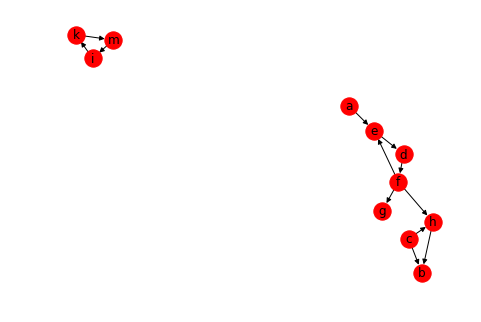

```python
Graphtype2 = nx.DiGraph()
Gdir2 = nx.from_pandas_edgelist(df2,source="Origin",target="Destination",edge_attr=None,  create_using=Graphtype2)
nx.draw(Gdir2,with_labels=True)
```

```python
list(nx.strongly_connected_components(Gdir2))
```

```
[{'b'}, {'h'}, {'g'}, {'d', 'e', 'f'}, {'a'}, {'c'}, {'i', 'k', 'm'}]
```

## Assignment

In the folder 1_Data you will find 6 csv files representing the network edgelist (Network_1.....6.csv) All the networks are undirected and unweighted except Network_3 (oriented and weighted) and Network_6 (oriented)

Divided in 2 groups , analyse the networks. For each network describe the gloabl measures and identify 5 nodes for which the centrality measures are the highest. What are the differences among the networks?

If you have the possibility try to plot the networks using gephi

You can present your results on power point

```
-Group A: Network_1, Network_2, Network_3
-Group B: Network_4, Network_5, Network_6
```

You can find all the networkx functions in the file: *Introduction to Network analysis.ipynb*